# Assignment 2

William Zou

2026-09-28

##1. Load and verify the data

```r
bank <- read.csv("UniversalBank.csv")

bank
```

[output not shown]

[output cut: 9987 more lines]

```r
summary(bank)
```

```
##        ID            Age          Experience       Income          ZIP.Code
##  Min.   :   1   Min.   :23.00   Min.   :-3.0   Min.   :  8.00   Min.   : 9307
##  1st Qu.:1251   1st Qu.:35.00   1st Qu.:10.0   1st Qu.: 39.00   1st Qu.:91911
##  Median :2500   Median :45.00   Median :20.0   Median : 64.00   Median :93437
##  Mean   :2500   Mean   :45.34   Mean   :20.1   Mean   : 73.77   Mean   :93153
##  3rd Qu.:3750   3rd Qu.:55.00   3rd Qu.:30.0   3rd Qu.: 98.00   3rd Qu.:94608
##  Max.   :5000   Max.   :67.00   Max.   :43.0   Max.   :224.00   Max.   :96651
##      Family          CCAvg          Education        Mortgage
##  Min.   :1.000   Min.   : 0.000   Min.   :1.000   Min.   :  0.0
##  1st Qu.:1.000   1st Qu.: 0.700   1st Qu.:1.000   1st Qu.:  0.0
##  Median :2.000   Median : 1.500   Median :2.000   Median :  0.0
##  Mean   :2.396   Mean   : 1.938   Mean   :1.881   Mean   : 56.5
##  3rd Qu.:3.000   3rd Qu.: 2.500   3rd Qu.:3.000   3rd Qu.:101.0
##  Max.   :4.000   Max.   :10.000   Max.   :3.000   Max.   :635.0
##  Personal.Loan   Securities.Account   CD.Account         Online
##  Min.   :0.000   Min.   :0.0000     Min.   :0.0000   Min.   :0.0000
##  1st Qu.:0.000   1st Qu.:0.0000     1st Qu.:0.0000   1st Qu.:0.0000
##  Median :0.000   Median :0.0000     Median :0.0000   Median :1.0000
##  Mean   :0.096   Mean   :0.1044     Mean   :0.0604   Mean   :0.5968
##  3rd Qu.:0.000   3rd Qu.:0.0000     3rd Qu.:0.0000   3rd Qu.:1.0000
##  Max.   :1.000   Max.   :1.0000     Max.   :1.0000   Max.   :1.0000
##    CreditCard
##  Min.   :0.000
##  1st Qu.:0.000
##  Median :0.000
##  Mean   :0.294
##  3rd Qu.:1.000
##  Max.   :1.000
```

```r
table(bank$Personal.Loan)
```

```
##
##    0    1
## 4520  480
```

##2. Remove ID and ZIP Code as predictors as instructed ##new data frame

```r
bank2 <- bank[,!(names(bank) %in% c("ID","ZIP.Code"))]

##check whether the predictors are properly removed
names(bank2)
```

```
##  [1] "Age"                "Experience"         "Income"
##  [4] "Family"             "CCAvg"              "Education"
##  [7] "Mortgage"           "Personal.Loan"      "Securities.Account"
## [10] "CD.Account"         "Online"             "CreditCard"
```

##3. Transform categorical preditor(s) with more than 2 categories into dummy VARs ##Namely “Educ” in the data frame has 3 distinct categories

```r
bank2$Education <- factor(bank2$Education)

bank2 <- cbind(
  bank2[, !(names(bank2) %in% "Education")],
  model.matrix(~ Education - 1, data = bank2)
  )

##Verify VARs
names(bank2)
```

```
##  [1] "Age"                "Experience"         "Income"
##  [4] "Family"             "CCAvg"              "Mortgage"
##  [7] "Personal.Loan"      "Securities.Account" "CD.Account"
## [10] "Online"             "CreditCard"         "Education1"
## [13] "Education2"         "Education3"
```

```r
##Newly added: Educ1, Educ2, Educ3
```

##4. Separate the predictors and the intended target ##Only want to know the output of loan approval - VAR = Personal.Loan

```r
x <- bank2[, names(bank2) !="Personal.Loan"]
y <- bank2$Personal.Loan
## x = predictors; y = target/output
```

##5. Load KNN package

```r
library(class)
```

##6. Partition the data frame into 60% ‘Training’ & 40% ‘Validation’

```r
##standardize the predictors, so everything is weighted equally in the model
x_scaled <- scale(x)

##60/40 split
##set seed so the random split is reproducible for the model, no fluctuation
library(caret)
set.seed(123)

train_index <- createDataPartition(y, p = 0.60, list = F)

x_train <- x_scaled[train_index, ]
x_valid <- x_scaled[-train_index, ]

y_train <- y[train_index]
y_valid <- y[-train_index]

##check whether the split is done properly; 5000 obs 3000(60)/2000(40)
nrow(x_train)
```

```
## [1] 3000
```

```r
nrow(x_valid)
```

```
## [1] 2000
```

##7. Consider the following customer ##Specify new customer parameter

```r
new_customer <- data.frame(
  Age = 40,
  Experience = 10,
  Income = 84,
  Family = 2,
  CCAvg = 2,
  Mortgage = 0,
  Securities.Account = 0,
  CD.Account = 0,
  Online = 1,
  CreditCard = 1,
  Education1 = 0,
  Education2 = 1,
  Education3 = 0
)

##scale new_customer, so it fits into scaled predictors
new_customer_scaled <- scale(
  new_customer,
  center = attr(x_scaled, "scaled:center"),
  scale = attr(x_scaled, "scaled:scale")
)

customer_pred <- knn(
  train = x_train,
  test = new_customer_scaled,
  cl = factor(y_train),
  k = 1
)

##verify prediction
customer_pred
```

```
## [1] 0
## Levels: 0 1
```

##8. Find K-value that balances between overfitting and ignoring predictor info ##Most fitting/best K-value

```r
##test different k-values, from 1 to 50
k_values <- 1:50

accuracy <- numeric(length(k_values))

for (i in seq_along(k_values)) {
  pred <- knn(
    train = x_train,
    test = x_valid,
    cl = factor(y_train),
    k = k_values[i]
  )

##compare predictions with validation results
  accuracy[i] <- mean(pred == factor(y_valid))
}

##table for each k-value and corresponding validation accuracy
k_results <- data.frame(
  k = k_values,
  Accuracy = accuracy
)

k_results
```

```
##     k Accuracy
## 1   1   0.9635
## 2   2   0.9595
## 3   3   0.9585
## 4   4   0.9540
## 5   5   0.9545
## 6   6   0.9535
## 7   7   0.9545
## 8   8   0.9515
## 9   9   0.9490
## 10 10   0.9480
## 11 11   0.9470
## 12 12   0.9490
## 13 13   0.9460
## 14 14   0.9465
```

[output cut: 36 more lines]

```r
##find the best k-value
k_best <- k_results$k[which.max(k_results$Accuracy)]

k_best
```

```
## [1] 1
```

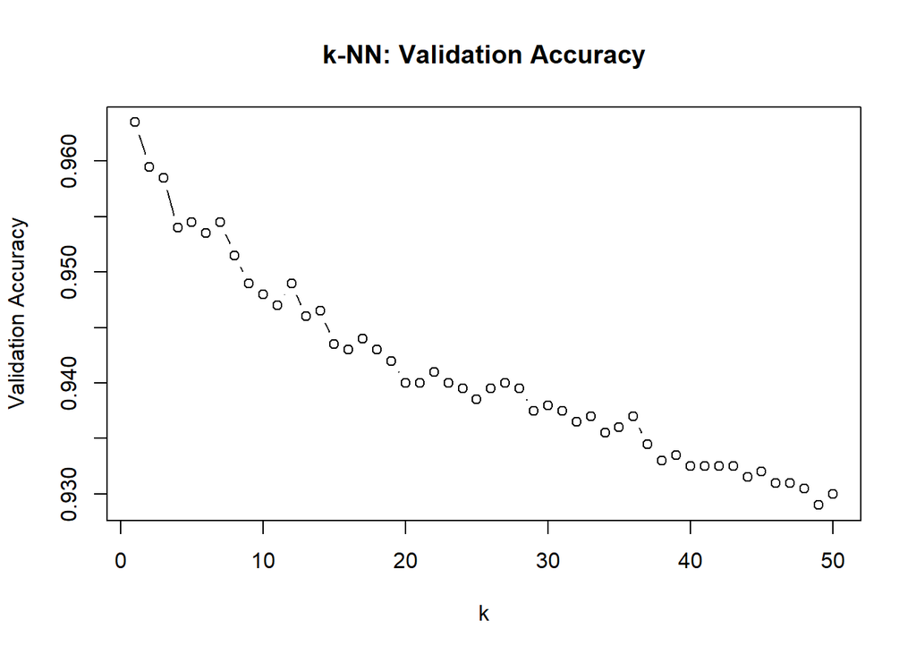

```r
##visual for better comparison
plot(
  k_results$k,
  k_results$Accuracy,
  type = "b",
  xlab = "k",
  ylab = "Validation Accuracy",
  main = "k-NN: Validation Accuracy"
)
```

##9. Confusion matrix

```r
pred_best <- knn(
  train = x_train,
  test = x_valid,
  cl = factor(y_train),
  k = k_best
)

confusion_valid <- table(
  Actual = y_valid,
  Predicted = pred_best
)

confusion_valid
```

```
##       Predicted
## Actual    0    1
##      0 1777   21
##      1   52  150
```

##10. Check accuracy of the matrix

```r
mean(pred_best == factor(y_valid))
```

```
## [1] 0.9635
```

##11. Classify customer using the best k-value

```r
customer_best <- knn(
  train = x_train,
  test = new_customer_scaled,
  cl = factor(y_train),
  k = k_best
)

customer_best
```

```
## [1] 0
## Levels: 0 1
```

```r
##R should return either 0 or 1; 0 being 'not accepting loan', 1 being ' accepting loan'
```

##12. Repartition the data into ‘Training’, ‘Validation’, ‘Test’

```r
##set seed so random split is reproducible for the new model
set.seed(123)

##first splitting data into 50% training and 50% pending for partition: validation (30); testing (20)
train_index2 <- createDataPartition(y, p = 0.50, list = F)

x_train2 <- x_scaled[train_index2, ]
X_remaining2 <- x_scaled[-train_index2, ]

y_train2 <- y[train_index2]
y_remaining2 <- y[-train_index2]

validation_index2 <- createDataPartition(y_remaining2, p = 0.60, list = F)

x_valid2 <- X_remaining2[validation_index2, ]
x_test2 <- X_remaining2[-validation_index2, ]

y_valid2 <- y_remaining2[validation_index2]
y_test2 <- y_remaining2[-validation_index2]

##verify whether the data is properly divided
##50% of 5000 = 2500
nrow(x_train2)
```

```
## [1] 2500
```

```r
##30% of 5K = 1500
nrow(x_valid2)
```

```
## [1] 1500
```

```r
##20% of 5K = 1000
nrow(x_test2)
```

```
## [1] 1000
```

##13. Apply KNN method with best k-value(k_best)

```r
pred_train2 <- knn(
  train = x_train2,
  test = x_train2,
  cl = factor(y_train2),
  k = k_best
)

pred_valid2 <- knn(
  train = x_train2,
  test = x_valid2,
  cl = factor(y_train2),
  k = k_best
)

pred_test2 <- knn(
  train = x_train2,
  test = x_test2,
  cl = factor(y_train2),
  k = k_best
)

pred_train2
```

[output not shown]

[output cut: 54 more lines]

```r
pred_valid2
```

[output not shown]

[output cut: 27 more lines]

```r
pred_test2
```

[output not shown]

##14. Confusion matrix for the datasets

```r
con_train <- table(
  Actual = y_train2,
  Predicted = pred_train2
)

con_train
```

```
##       Predicted
## Actual    0    1
##      0 2271    0
##      1    0  229
```

```r
con_valid <- table(
  Actual = y_valid2,
  Predicted = pred_valid2
)

con_valid
```

```
##       Predicted
## Actual    0    1
##      0 1335   22
##      1   42  101
```

```r
con_test <- table(
  Actual = y_test2,
  Predicted = pred_test2
)

con_test
```

```
##       Predicted
## Actual   0   1
##      0 885   7
##      1  29  79
```

##15. Check accuracy of the matrix

```r
accuracy_train <- mean(pred_train2 == factor(y_train2))

accuracy_valid <- mean(pred_valid2 == factor(y_valid2))

accuracy_test <- mean(pred_test2 == factor(y_test2))

accuracy_comparison <- c(
  Training = accuracy_train,
  Validation = accuracy_valid,
  Test = accuracy_test
)

accuracy_comparison
```

```
##   Training Validation       Test
##  1.0000000  0.9573333  0.9640000
```

##The ‘Training’ accuracy is 100%, while ‘Validation’ accuracy is 95.7% and ‘Test’ accuracy were is 96.4%. The higher accuracy in ‘Training’ is expected because the model is trained on the given observations, whereas ‘Validation’ and ‘Test’ are lower because they contain observations that the model is not trained on these observations. The difference between ‘Training’ and ‘Validation’/‘Test’ suggests some overfitting; however, given how similar the ‘Validation’ accuracy is to the ‘Test’ accuracy, the overfitting issue is not severe and the model generalizes well to unseen data.